# **Reproducible Research Course Project 1**

### June 2015

## **1.Loading and preprocessing the data**

Show any code that is needed to load and process the data (if necessary) into a format suitable for your analysis. *I use the read.csv() function to read the data for the project.*

```r
library(knitr)
library(gridExtra)
```

```r
library(ggplot2)
library(plyr)
library(dplyr)
file_name = "activity.zip"
Url = "http://d396qusza40orc.cloudfront.net/repdata%2Fdata%2Factivity.zip"
if (!file.exists(file_name)) {
        download.file(Url, destfile = file_name) }
csv_file <- unz(file_name, "activity.csv")
```

```r
act <- read.csv(csv_file, header = T, colClasses = c("integer", "character","integer"),na.strings="NA",sep=",")
```

```r
str(act)
```

```
## 'data.frame':    17568 obs. of  3 variables:
##  $ steps   : int  NA NA NA NA NA NA NA NA NA NA ...
##  $ date    : chr  "2012-10-01" "2012-10-01" "2012-10-01" "2012-10-01" ...
##  $ interval: int  0 5 10 15 20 25 30 35 40 45 ...
```

## **2.What is mean total number of steps taken per day?**

2.1.For this part of the assignment, you can ignore the missing values in the dataset and calculate the total number of steps taken per day. Make a histogram of the total number of steps taken each day. *In constructing the histogram for the total number of steps taken per day, I use the tapply() function to calculate the sum of the activities per day.*

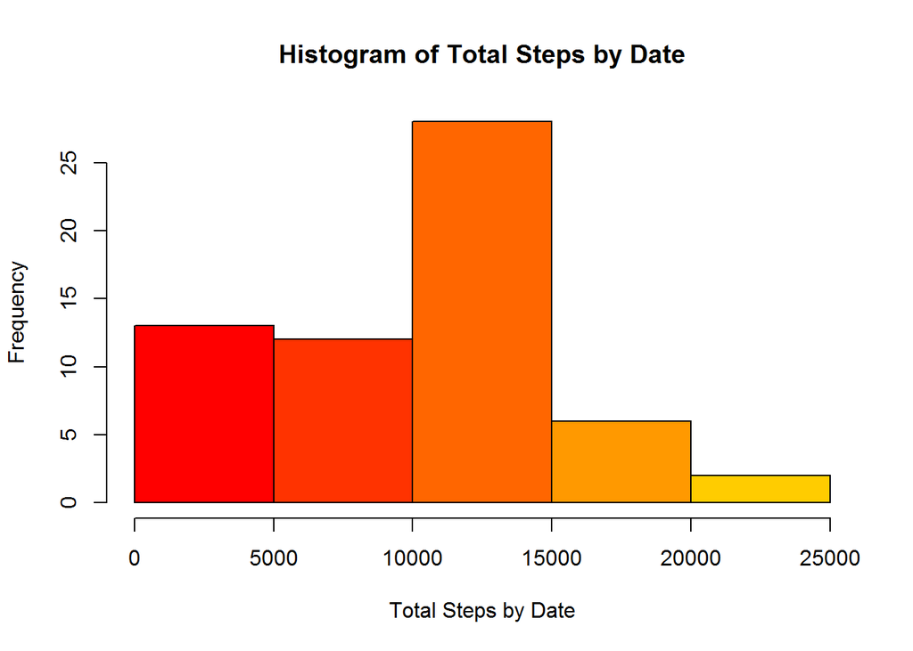

```r
sum_by_date <- tapply(act$steps,act$date,sum,na.rm=TRUE)
hist(sum_by_date,col=heat.colors(8),xlab="Total Steps by Date",main="Histogram of Total Steps by Date")
```

2.2.Calculate and report the mean and median of the total number of steps taken per day.

```r
mean(sum_by_date)
```

```
## [1] 9354.23
```

```r
median(sum_by_date)
```

```
## [1] 10395
```

## **3.What is the average daily activity pattern?**

3.1.Make a time series plot of the 5-minute interval (x-axis) and the average number of steps taken, averaged across all days (y-axis). *First, I use tapply() to calculate the mean of the steps per interval. Next, the data is implemented in the time series plot below.*

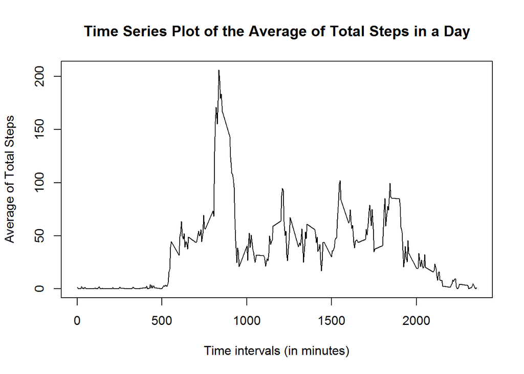

```r
mean_by_int <- tapply(act$steps,act$interval,mean,na.rm=TRUE)
plot(row.names(mean_by_int),mean_by_int,type="l",xlab="Time intervals (in minutes)",ylab="Average of Total Steps",main="Time Series Plot of the Average of Total Steps in a Day")
```

3.2.Which 5-minute interval, on average across all the days in the dataset, contains the maximum number of steps? *The answer is time interval **835** with maximum number of steps 206. First, I obtain the max value of the mean_by_int vector, which contains the mean of every interval. Next I use the match() function to find the index of the max value of the mean_by_int vector. Finally, I access the location of the vector.*

```r
x <- max(mean_by_int)
match(x,mean_by_int)
```

```
## [1] 104
```

```r
mean_by_int[104]
```

```
##      835
## 206.1698
```

# **4.Imputing missing values**

4.1.Calculate and report the total number of missing values in the dataset. *I use the sum() and is.na() functions to accomplish this task.*

```r
sum(is.na(act))
```

```
## [1] 2304
```

*So the original data set has **2304** rows with missing data*

4.2.Devise a strategy for filling in all of the missing values in the dataset. Create a new dataset that is equal to the original dataset but with the missing data filled in. *I first create two separate data frames, one without NAs and one with all rows with NA values for the steps vector. Next, I insert the mean_by_int vector into the data frame that contains all NAs for the steps variable. Then I bind the data frame with no NAs with the data frame that now contains all of the mean values for the corresponding time intervals. Finally a new dataset is created that is equal to the original dataset but with the missing data filled in.*

```r
act_na <- act[is.na(act),]
act_no_na <- act[complete.cases(act),]
act_na$steps <- as.numeric(mean_by_int)
new_act <- rbind(act_na,act_no_na)
new_act <- new_act[order(new_act[,2],new_act[,3]),]
```

4.3.Make a histogram of the total number of steps taken each day and Calculate and report the mean and median total number of steps taken per day. *For the histogram, I used tapply() function to calculate the daily sums of total steps from the new dataset. I also calculated the mean and median for the new dataset.*

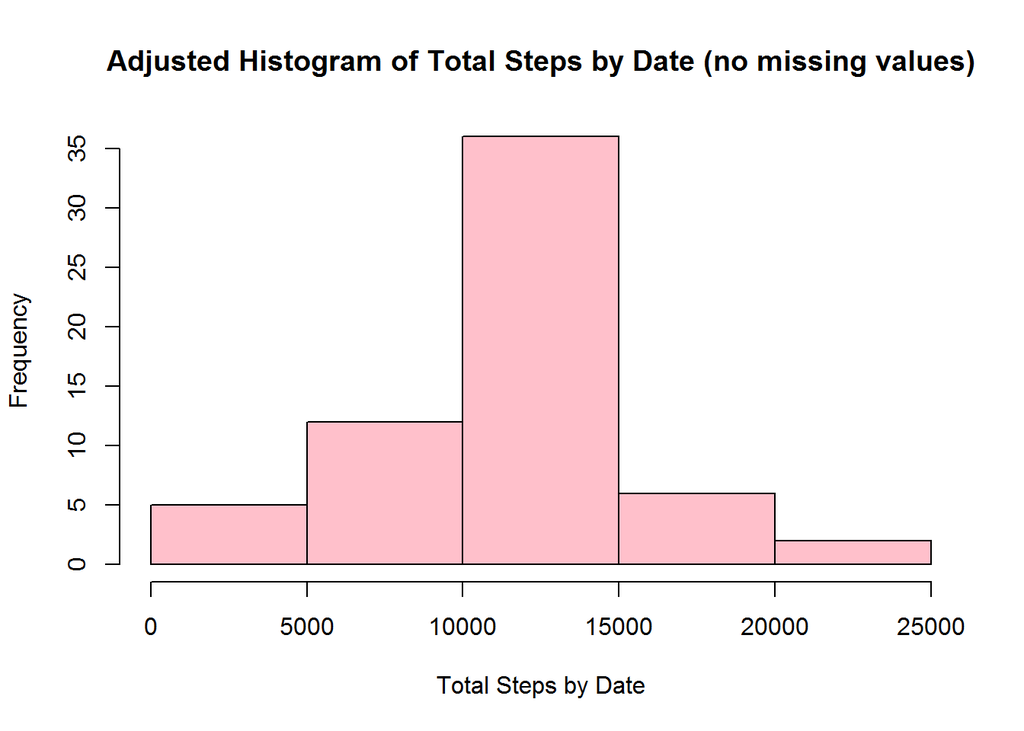

```r
new_sum_by_date <- tapply(new_act$steps,new_act$date,sum)
hist(new_sum_by_date,col="pink",xlab="Total Steps by Date",main="Adjusted Histogram of Total Steps by Date (no missing values)")
```

```r
mean(new_sum_by_date)
```

```
## [1] 10766.19
```

```r
median(new_sum_by_date)
```

```
## [1] 10766.19
```

4.4.Do these values differ from the estimates from the first part of the assignment? What is the impact of imputing missing data on the estimates of the total daily number of steps? *In comparing the histogram with the data frame that contained missing values against the data frame that had the missing values filled in, there is a change on the left side of the graph. In the first histogram, the data is skewed to the left although the data represents a normal distribution curve. In the second histogram, the data very closely resembles a normal distribution curve. Imputing the missing data on the data frame possibly allows a more accurate distribution of the data.*

*For the mean and median of the new data set, there was an unusual phenomenon. The mean and meadian for the total steps per day were both 10766.19. This figure seems to confirm from the histogram that imputing the missing data with the mean averages from the time intervals helps to create a normal distribution of the total steps.*

## **5.Are there differences in activity patterns between weekdays and weekends?**

5.1.Create a new factor variable in the dataset with two levels - “weekday” and “weekend” indicating whether a given date is a weekday or weekend day. *I used the weekdays() function to generate a vector of the weekdays according to the date. Next, I combined the activity data frame with the newly created days vector. I utilized the plyr library so I could implement the revalue() function. Finally, I used the aforementioned function to convert the days to weekend or weekday as instructed.*

```r
days <- weekdays(as.Date(new_act[,2]))
new_act <- cbind(new_act,days)
library(plyr)
new_act$days <- revalue(new_act$days,c("lunes"="weekday","martes"="weekday","miércoles"="weekday","jueves"="weekday","viernes"="weekday","sábado"="weekend",
"domingo"="weekend"))
```

5.2.Make a panel plot containing a time series plot (i.e. type = “l”) of the 5-minute interval (x-axis) and the average number of steps taken, averaged across all weekday days or weekend days (y-axis). *For this part, I first used the tapply() function to create a dataset that contained the mean of the intervals and group them according to the day (weekday or weekend). Next, I used the reshape2 library to implement the melt command on the newly created dataset of mean of the intervals for the total steps. Finally, I created a lattice plot to show the time series plot of the mean total steps by the intervals for the weekday and the weekend.*

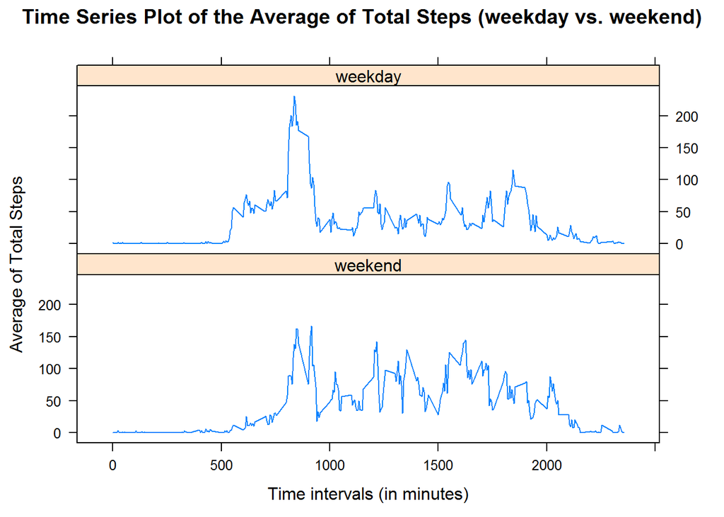

```r
new_mean_by_int <- tapply(new_act$steps,list(new_act$interval,new_act$days),mean)
library(reshape2)
new_mean_by_int <- melt(new_mean_by_int)
colnames(new_mean_by_int) <- c("interval","day","steps")
library(lattice)
xyplot(new_mean_by_int$steps ~ new_mean_by_int$interval | new_mean_by_int$day, layout=c(1,2),type="l",main="Time Series Plot of the Average of Total Steps (weekday vs. weekend)",xlab="Time intervals (in minutes)",ylab="Average of Total Steps")
```

*The time plot shows that there is more activity after the 1000 time interval on the weekend instead of the weekday. However, the plot also shows that the most steps are taken during a time interval during the weekday (possibly the 835 time interval).*